# Predict Bike Sharing Demand with AutoGluon

## Project: Predict Bike Sharing Demand with AutoGluon

This notebook is a template with each step that you need to complete for the project.

Please fill in your code where there are explicit `?` markers in the notebook. You are welcome to add more cells and code as you see fit.

Once you have completed all the code implementations, please export your notebook as a HTML file so the reviews can view your code. Make sure you have all outputs correctly outputted.

`File-> Export Notebook As... -> Export Notebook as HTML`

There is a writeup to complete as well after all code implememtation is done. Please answer all questions and attach the necessary tables and charts. You can complete the writeup in either markdown or PDF.

Completing the code template and writeup template will cover all of the rubric points for this project.

The rubric contains "Stand Out Suggestions" for enhancing the project beyond the minimum requirements. The stand out suggestions are optional. If you decide to pursue the "stand out suggestions", you can include the code in this notebook and also discuss the results in the writeup file.

## Step 1: Create an account with Kaggle

### Create Kaggle Account and download API key

Below is example of steps to get the API username and key. Each student will have their own username and key.

1. Open account settings.
2. Scroll down to API and click Create New API Token.
3. Open up `kaggle.json` and use the username and key.

## Step 2: Download the Kaggle dataset using the kaggle python library

### Open up Sagemaker Studio and use starter template

1. Notebook should be using a `ml.t3.medium` instance (2 vCPU + 4 GiB)
2. Notebook should be using kernal: `Python 3 (MXNet 1.8 Python 3.7 CPU Optimized)`

### Install packages

```python
!pip install -U setuptools wheel
!pip install -U "mxnet<2.0.0" bokeh==2.0.1
!pip install autogluon --no-cache-dir
# Without --no-cache-dir, smaller aws instances may have trouble installing
```

[output not shown]

[output cut: 192 more lines]

[output not shown]

### Setup Kaggle API Key

```python
# create the .kaggle directory and an empty kaggle.json file
!mkdir -p /root/.kaggle
!touch /root/.kaggle/kaggle.json
!chmod 600 /root/.kaggle/kaggle.json
```

```python
# Fill in your user name and key from creating the kaggle account and API token file
import json
kaggle_username = "jahnvisahni31"
kaggle_key = "1d0230ab17a1bc876c003245091c7a49"

# Save API token the kaggle.json file
with open("/root/.kaggle/kaggle.json", "w") as f:
    f.write(json.dumps({"username": kaggle_username, "key": kaggle_key}))
```

### Download and explore dataset

### Go to the bike sharing demand competition and agree to the terms

```python
# Download the dataset, it will be in a .zip file so you'll need to unzip it as well.
!kaggle competitions download -c bike-sharing-demand
# If you already downloaded it you can use the -o command to overwrite the file
!unzip -o bike-sharing-demand.zip
```

```
Downloading bike-sharing-demand.zip to /content
  0% 0.00/189k [00:00<?, ?B/s]
100% 189k/189k [00:00<00:00, 72.9MB/s]
Archive:  bike-sharing-demand.zip
  inflating: sampleSubmission.csv
  inflating: test.csv
  inflating: train.csv
```

```python
import pandas as pd
from autogluon.tabular import TabularPredictor
```

```python
# Create the train dataset in pandas by reading the csv
# Set the parsing of the datetime column so you can use some of the `dt` features in pandas later
train = pd.read_csv("train.csv", parse_dates=['datetime'])
train.head()
```

|  | datetime | season | holiday | workingday | weather | temp | atemp | humidity | windspeed | casual | registered | count |
| --- | --- | --- | --- | --- | --- | --- | --- | --- | --- | --- | --- | --- |
| 0 | 2011-01-01 00:00:00 | 1 | 0 | 0 | 1 | 9.84 | 14.395 | 81 | 0.0 | 3 | 13 | 16 |
| 1 | 2011-01-01 01:00:00 | 1 | 0 | 0 | 1 | 9.02 | 13.635 | 80 | 0.0 | 8 | 32 | 40 |
| 2 | 2011-01-01 02:00:00 | 1 | 0 | 0 | 1 | 9.02 | 13.635 | 80 | 0.0 | 5 | 27 | 32 |
| 3 | 2011-01-01 03:00:00 | 1 | 0 | 0 | 1 | 9.84 | 14.395 | 75 | 0.0 | 3 | 10 | 13 |
| 4 | 2011-01-01 04:00:00 | 1 | 0 | 0 | 1 | 9.84 | 14.395 | 75 | 0.0 | 0 | 1 | 1 |

```python
# Simple output of the train dataset to view some of the min/max/varition of the dataset features.
train.describe()
```

|  | datetime | season | holiday | workingday | weather | temp | atemp | humidity | windspeed | casual | registered | count |
| --- | --- | --- | --- | --- | --- | --- | --- | --- | --- | --- | --- | --- |
| count | 10886 | 10886.000000 | 10886.000000 | 10886.000000 | 10886.000000 | 10886.00000 | 10886.000000 | 10886.000000 | 10886.000000 | 10886.000000 | 10886.000000 | 10886.000000 |
| mean | 2011-12-27 05:56:22.399411968 | 2.506614 | 0.028569 | 0.680875 | 1.418427 | 20.23086 | 23.655084 | 61.886460 | 12.799395 | 36.021955 | 155.552177 | 191.574132 |
| min | 2011-01-01 00:00:00 | 1.000000 | 0.000000 | 0.000000 | 1.000000 | 0.82000 | 0.760000 | 0.000000 | 0.000000 | 0.000000 | 0.000000 | 1.000000 |
| 25% | 2011-07-02 07:15:00 | 2.000000 | 0.000000 | 0.000000 | 1.000000 | 13.94000 | 16.665000 | 47.000000 | 7.001500 | 4.000000 | 36.000000 | 42.000000 |
| 50% | 2012-01-01 20:30:00 | 3.000000 | 0.000000 | 1.000000 | 1.000000 | 20.50000 | 24.240000 | 62.000000 | 12.998000 | 17.000000 | 118.000000 | 145.000000 |
| 75% | 2012-07-01 12:45:00 | 4.000000 | 0.000000 | 1.000000 | 2.000000 | 26.24000 | 31.060000 | 77.000000 | 16.997900 | 49.000000 | 222.000000 | 284.000000 |
| max | 2012-12-19 23:00:00 | 4.000000 | 1.000000 | 1.000000 | 4.000000 | 41.00000 | 45.455000 | 100.000000 | 56.996900 | 367.000000 | 886.000000 | 977.000000 |
| std | NaN | 1.116174 | 0.166599 | 0.466159 | 0.633839 | 7.79159 | 8.474601 | 19.245033 | 8.164537 | 49.960477 | 151.039033 | 181.144454 |

```python
# Create the test pandas dataframe in pandas by reading the csv, remember to parse the datetime!
test = pd.read_csv("test.csv", parse_dates=['datetime'])
test.head()
```

|  | datetime | season | holiday | workingday | weather | temp | atemp | humidity | windspeed |
| --- | --- | --- | --- | --- | --- | --- | --- | --- | --- |
| 0 | 2011-01-20 00:00:00 | 1 | 0 | 1 | 1 | 10.66 | 11.365 | 56 | 26.0027 |
| 1 | 2011-01-20 01:00:00 | 1 | 0 | 1 | 1 | 10.66 | 13.635 | 56 | 0.0000 |
| 2 | 2011-01-20 02:00:00 | 1 | 0 | 1 | 1 | 10.66 | 13.635 | 56 | 0.0000 |
| 3 | 2011-01-20 03:00:00 | 1 | 0 | 1 | 1 | 10.66 | 12.880 | 56 | 11.0014 |
| 4 | 2011-01-20 04:00:00 | 1 | 0 | 1 | 1 | 10.66 | 12.880 | 56 | 11.0014 |

```python
# Same thing as train and test dataset
submission = pd.read_csv("sampleSubmission.csv", parse_dates=['datetime'])
submission.head()
```

|  | datetime | count |
| --- | --- | --- |
| 0 | 2011-01-20 00:00:00 | 0 |
| 1 | 2011-01-20 01:00:00 | 0 |
| 2 | 2011-01-20 02:00:00 | 0 |
| 3 | 2011-01-20 03:00:00 | 0 |
| 4 | 2011-01-20 04:00:00 | 0 |

## Step 3: Train a model using AutoGluon’s Tabular Prediction

Requirements:

- We are prediting `count`, so it is the label we are setting.
- Ignore `casual` and `registered` columns as they are also not present in the test dataset.
- Use the `root_mean_squared_error` as the metric to use for evaluation.
- Set a time limit of 10 minutes (600 seconds).
- Use the preset `best_quality` to focus on creating the best model.

```python
label = 'count'
ignore_columns = ['casual', 'registered']
eval_metric = 'root_mean_squared_error'
time_limit = 600
preset = 'best_quality'
```

```python
predictor = TabularPredictor(label=label,problem_type= 'regression',eval_metric=eval_metric,learner_kwargs={'ignored_columns': ignore_columns})
predictor.fit(train,time_limit=time_limit,presets=preset)
```

[output not shown]

[output cut: 80 more lines]

```
	Fitting 8 child models (S1F1 - S1F8) | Fitting with ParallelLocalFoldFittingStrategy (2 workers, per: cpus=1, gpus=0, memory=0.11%)
	-55.0881	 = Validation score   (-root_mean_squared_error)
	30.71s	 = Training   runtime
	0.25s	 = Validation runtime
Fitting model: RandomForestMSE_BAG_L2 ... Training model for up to 30.4s of the 30.36s of remaining time.
	-53.497	 = Validation score   (-root_mean_squared_error)
	45.3s	 = Training   runtime
	0.67s	 = Validation runtime
Fitting model: WeightedEnsemble_L3 ... Training model for up to 360.0s of the -17.53s of remaining time.
	Ensemble Weights: {'RandomForestMSE_BAG_L2': 0.7, 'LightGBM_BAG_L2': 0.25, 'LightGBMXT_BAG_L2': 0.05}
	-53.1533	 = Validation score   (-root_mean_squared_error)
	0.07s	 = Training   runtime
	0.0s	 = Validation runtime
AutoGluon training complete, total runtime = 421.64s ... Best model: "WeightedEnsemble_L3"
TabularPredictor saved. To load, use: predictor = TabularPredictor.load("AutogluonModels/ag-20240427_204535")
```

```
<autogluon.tabular.predictor.predictor.TabularPredictor at 0x7b7afdeb7700>
```

### Review AutoGluon's training run with ranking of models that did the best.

```python
predictor.fit_summary()
```

```
*** Summary of fit() ***
Estimated performance of each model:
                     model   score_val              eval_metric  pred_time_val    fit_time  pred_time_val_marginal  fit_time_marginal  stack_level  can_infer  fit_order
0      WeightedEnsemble_L3  -53.153263  root_mean_squared_error      19.729153  390.452654                0.001075           0.065069            3       True         12
1   RandomForestMSE_BAG_L2  -53.497019  root_mean_squared_error      14.356505  295.233102                0.673781          45.297034            2       True         11
2          LightGBM_BAG_L2  -55.088119  root_mean_squared_error      13.928132  280.648894                0.245408          30.712826            2       True         10
3        LightGBMXT_BAG_L2  -60.362835  root_mean_squared_error      18.808890  314.377725                5.126166          64.441658            2       True          9
4    KNeighborsDist_BAG_L1  -84.125061  root_mean_squared_error       0.067172    0.048740                0.067172           0.048740            1       True          2
5      WeightedEnsemble_L2  -84.125061  root_mean_squared_error       0.068133    0.077715                0.000962           0.028975            2       True          8
6    KNeighborsUnif_BAG_L1 -101.546199  root_mean_squared_error       0.067264    0.049548                0.067264           0.049548            1       True          1
7   RandomForestMSE_BAG_L1 -116.548359  root_mean_squared_error       0.811516   18.842767                0.811516          18.842767            1       True          5
8     ExtraTreesMSE_BAG_L1 -124.600676  root_mean_squared_error       0.597689    7.957541                0.597689           7.957541            1       True          7
9          CatBoost_BAG_L1 -130.920545  root_mean_squared_error       0.222526  113.010389                0.222526         113.010389            1       True          6
10         LightGBM_BAG_L1 -131.054162  root_mean_squared_error       2.572374   34.517408                2.572374          34.517408            1       True          4
11       LightGBMXT_BAG_L1 -131.460909  root_mean_squared_error       9.344183   75.509674                9.344183          75.509674            1       True          3
Number of models trained: 12
Types of models trained:
{'StackerEnsembleModel_RF', 'WeightedEnsembleModel', 'StackerEnsembleModel_LGB', 'StackerEnsembleModel_KNN', 'StackerEnsembleModel_CatBoost', 'StackerEnsembleModel_XT'}
Bagging used: True  (with 8 folds)
Multi-layer stack-ensembling used: True  (with 3 levels)
Feature Metadata (Processed):
(raw dtype, special dtypes):
('float', [])                : 3 | ['temp', 'atemp', 'windspeed']
('int', [])                  : 3 | ['season', 'weather', 'humidity']
('int', ['bool'])            : 2 | ['holiday', 'workingday']
('int', ['datetime_as_int']) : 5 | ['datetime', 'datetime.year', 'datetime.month', 'datetime.day', 'datetime.dayofweek']
*** End of fit() summary ***
```

[output not shown]

[output cut: 102 more lines]

```
 11       9.344183   75.509674                9.344183          75.509674

     stack_level  can_infer  fit_order
 0             3       True         12
 1             2       True         11
 2             2       True         10
 3             2       True          9
 4             1       True          2
 5             2       True          8
 6             1       True          1
 7             1       True          5
 8             1       True          7
 9             1       True          6
 10            1       True          4
 11            1       True          3  }
```

```python
# Leaderboard dataframe
leaderboard_df = pd.DataFrame(predictor.leaderboard(silent=True))
leaderboard_df
```

|  | model | score_val | eval_metric | pred_time_val | fit_time | pred_time_val_marginal | fit_time_marginal | stack_level | can_infer | fit_order |
| --- | --- | --- | --- | --- | --- | --- | --- | --- | --- | --- |
| 0 | WeightedEnsemble_L3 | -53.153263 | root_mean_squared_error | 19.729153 | 390.452654 | 0.001075 | 0.065069 | 3 | True | 12 |
| 1 | RandomForestMSE_BAG_L2 | -53.497019 | root_mean_squared_error | 14.356505 | 295.233102 | 0.673781 | 45.297034 | 2 | True | 11 |
| 2 | LightGBM_BAG_L2 | -55.088119 | root_mean_squared_error | 13.928132 | 280.648894 | 0.245408 | 30.712826 | 2 | True | 10 |
| 3 | LightGBMXT_BAG_L2 | -60.362835 | root_mean_squared_error | 18.808890 | 314.377725 | 5.126166 | 64.441658 | 2 | True | 9 |
| 4 | KNeighborsDist_BAG_L1 | -84.125061 | root_mean_squared_error | 0.067172 | 0.048740 | 0.067172 | 0.048740 | 1 | True | 2 |
| 5 | WeightedEnsemble_L2 | -84.125061 | root_mean_squared_error | 0.068133 | 0.077715 | 0.000962 | 0.028975 | 2 | True | 8 |
| 6 | KNeighborsUnif_BAG_L1 | -101.546199 | root_mean_squared_error | 0.067264 | 0.049548 | 0.067264 | 0.049548 | 1 | True | 1 |
| 7 | RandomForestMSE_BAG_L1 | -116.548359 | root_mean_squared_error | 0.811516 | 18.842767 | 0.811516 | 18.842767 | 1 | True | 5 |
| 8 | ExtraTreesMSE_BAG_L1 | -124.600676 | root_mean_squared_error | 0.597689 | 7.957541 | 0.597689 | 7.957541 | 1 | True | 7 |
| 9 | CatBoost_BAG_L1 | -130.920545 | root_mean_squared_error | 0.222526 | 113.010389 | 0.222526 | 113.010389 | 1 | True | 6 |
| 10 | LightGBM_BAG_L1 | -131.054162 | root_mean_squared_error | 2.572374 | 34.517408 | 2.572374 | 34.517408 | 1 | True | 4 |
| 11 | LightGBMXT_BAG_L1 | -131.460909 | root_mean_squared_error | 9.344183 | 75.509674 | 9.344183 | 75.509674 | 1 | True | 3 |

### Create predictions from test dataset

```python
predictions = predictor.predict(test)
predictions.head()
```

```
0    23.353573
1    43.482906
2    46.300312
3    48.930107
4    51.659828
Name: count, dtype: float32
```

#### NOTE: Kaggle will reject the submission if we don't set everything to be > 0.

```python
# Describe the `predictions` series to see if there are any negative values
predictions.describe()
```

```
count    6493.000000
mean      100.469284
std        89.915565
min         3.093397
25%        19.565144
50%        64.048050
75%       168.326080
max       368.692749
Name: count, dtype: float64
```

```python
# How many negative values do we have?
negative_pred_count = predictions.apply(lambda x: 1 if x<0 else 0)
pred_neg_count = (negative_pred_count==1).sum()

print("Total predictions                :", len(predictions.index))
print("Total negative prediction values :", pred_neg_count)
```

```
Total predictions                : 6493
Total negative prediction values : 0
```

```python
# Set them to zero
predictions[predictions<0] = 0
```

### Set predictions to submission dataframe, save, and submit

```python
submission["count"] = predictions
submission.to_csv("submission.csv", index=False)
```

```python
!kaggle competitions submit -c bike-sharing-demand -f submission.csv -m "first raw submission"
```

#### View submission via the command line or in the web browser under the competition's page - `My Submissions`

```python
!kaggle competitions submissions -c bike-sharing-demand | tail -n +1 | head -n 6
```

[output not shown]

## Step 4: Exploratory Data Analysis and Creating an additional feature

- Any additional feature will do, but a great suggestion would be to separate out the datetime into hour, day, or month parts.

```
array([[<Axes: title={'center': 'datetime'}>,
        <Axes: title={'center': 'season'}>,
        <Axes: title={'center': 'holiday'}>],
       [<Axes: title={'center': 'workingday'}>,
        <Axes: title={'center': 'weather'}>,
        <Axes: title={'center': 'temp'}>],
       [<Axes: title={'center': 'atemp'}>,
        <Axes: title={'center': 'humidity'}>,
        <Axes: title={'center': 'windspeed'}>],
       [<Axes: title={'center': 'casual'}>,
        <Axes: title={'center': 'registered'}>,
        <Axes: title={'center': 'count'}>]], dtype=object)
```

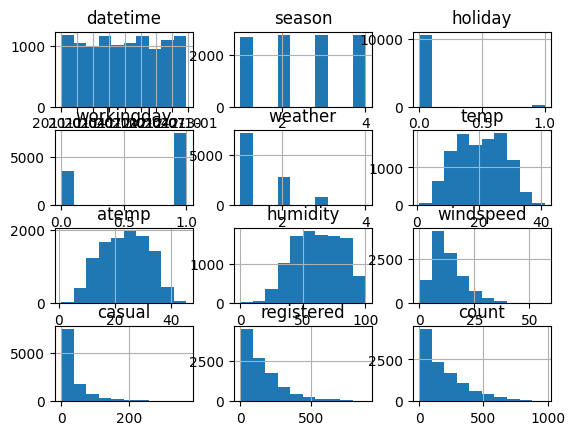

```python
# Create a histogram of all features to show the distribution of each one relative to the data. This is part of the exploritory data analysis
train.hist()
```

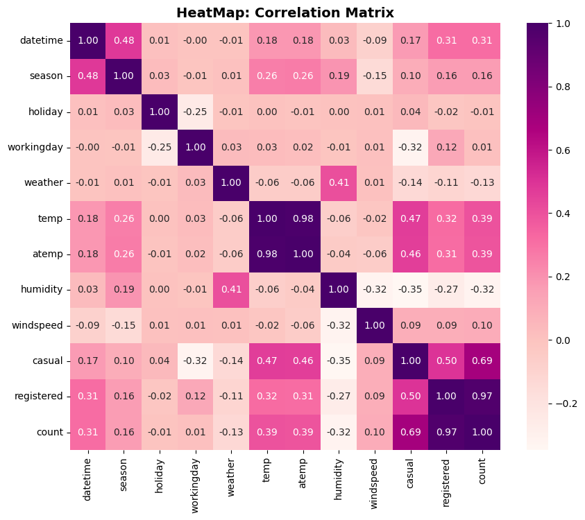

```python
#Plot Heatmap using Correlation Matrix
## Let's check the correlation between these variables to see if there is pattern between variables
import seaborn as sns
import matplotlib.pyplot as plt

plt.figure(figsize=(10, 8))
corr_matrix = train.corr()
sns.heatmap(corr_matrix, cmap='RdPu', annot=True, fmt=".2f", annot_kws={"size": 10})
plt.title("HeatMap: Correlation Matrix", fontsize=14, fontweight='bold')
plt.show()
```

```python
# create a new feature
train["year"] = train["datetime"].dt.year
train["month"] = train["datetime"].dt.month
train["day"] = train["datetime"].dt.dayofweek  # Note: day -> dayofweek (0->Monday, 6->Sunday)
train["hour"] = train["datetime"].dt.hour
train.drop(["datetime"], axis=1, inplace=True)     # Drop 'datetime' feature
train.head()
# Splitting the 'datetime' feature in test data
test["year"] = test["datetime"].dt.year
test["month"] = test["datetime"].dt.month
test["day"] = test["datetime"].dt.dayofweek  # Note: day -> dayofweek (0->Monday, 6->Sunday)
test["hour"] = test["datetime"].dt.hour
test.drop(["datetime"], axis=1, inplace=True)   # Drop 'datetime' feature
test.head()
```

|  | season | holiday | workingday | weather | temp | atemp | humidity | windspeed | year | month | day | hour |
| --- | --- | --- | --- | --- | --- | --- | --- | --- | --- | --- | --- | --- |
| 0 | 1 | 0 | 1 | 1 | 10.66 | 11.365 | 56 | 26.0027 | 2011 | 1 | 3 | 0 |
| 1 | 1 | 0 | 1 | 1 | 10.66 | 13.635 | 56 | 0.0000 | 2011 | 1 | 3 | 1 |
| 2 | 1 | 0 | 1 | 1 | 10.66 | 13.635 | 56 | 0.0000 | 2011 | 1 | 3 | 2 |
| 3 | 1 | 0 | 1 | 1 | 10.66 | 12.880 | 56 | 11.0014 | 2011 | 1 | 3 | 3 |
| 4 | 1 | 0 | 1 | 1 | 10.66 | 12.880 | 56 | 11.0014 | 2011 | 1 | 3 | 4 |

## Make category types for these so models know they are not just numbers

- AutoGluon originally sees these as ints, but in reality they are int representations of a category.
- Setting the dtype to category will classify these as categories in AutoGluon.

```python
train["season"] = train["season"].astype("category")
train["weather"] = train["weather"].astype("category")

test["season"] = test["season"].astype("category")
test["weather"] = test["weather"].astype("category")
```

```python
# View are new feature
train.head()
```

|  | season | holiday | workingday | weather | temp | atemp | humidity | windspeed | casual | registered | count | year | month | day | hour |
| --- | --- | --- | --- | --- | --- | --- | --- | --- | --- | --- | --- | --- | --- | --- | --- |
| 0 | 1 | 0 | 0 | 1 | 9.84 | 14.395 | 81 | 0.0 | 3 | 13 | 16 | 2011 | 1 | 5 | 0 |
| 1 | 1 | 0 | 0 | 1 | 9.02 | 13.635 | 80 | 0.0 | 8 | 32 | 40 | 2011 | 1 | 5 | 1 |
| 2 | 1 | 0 | 0 | 1 | 9.02 | 13.635 | 80 | 0.0 | 5 | 27 | 32 | 2011 | 1 | 5 | 2 |
| 3 | 1 | 0 | 0 | 1 | 9.84 | 14.395 | 75 | 0.0 | 3 | 10 | 13 | 2011 | 1 | 5 | 3 |
| 4 | 1 | 0 | 0 | 1 | 9.84 | 14.395 | 75 | 0.0 | 0 | 1 | 1 | 2011 | 1 | 5 | 4 |

```
array([[<Axes: title={'center': 'holiday'}>,
        <Axes: title={'center': 'workingday'}>,
        <Axes: title={'center': 'temp'}>,
        <Axes: title={'center': 'atemp'}>],
       [<Axes: title={'center': 'humidity'}>,
        <Axes: title={'center': 'windspeed'}>,
        <Axes: title={'center': 'casual'}>,
        <Axes: title={'center': 'registered'}>],
       [<Axes: title={'center': 'count'}>,
        <Axes: title={'center': 'year'}>,
        <Axes: title={'center': 'month'}>,
        <Axes: title={'center': 'day'}>],
       [<Axes: title={'center': 'hour'}>, <Axes: >, <Axes: >, <Axes: >]],
      dtype=object)
```

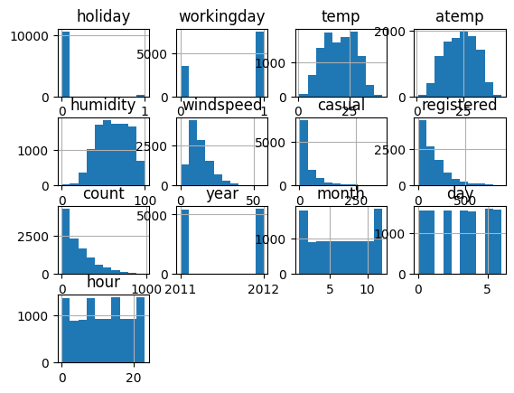

```python
# View histogram of all features again now with the hour feature
train.hist()
```

## Step 5: Rerun the model with the same settings as before, just with more features

```python
eval_metric = 'root_mean_squared_error'
label = 'count'
ignore_columns = ["casual", "registered"]
time_limit = 600
preset = "best_quality"
```

```python
predictor_new_features =  TabularPredictor(label=label,problem_type= 'regression',eval_metric=eval_metric,learner_kwargs={'ignored_columns': ignore_columns})
predictor_new_features.fit(train,time_limit=time_limit,presets=preset)
```

[output not shown]

[output cut: 82 more lines]

```
	-34.7092	 = Validation score   (-root_mean_squared_error)
	41.79s	 = Training   runtime
	0.68s	 = Validation runtime
Fitting model: CatBoost_BAG_L2 ... Training model for up to 16.7s of the 16.64s of remaining time.
	Fitting 8 child models (S1F1 - S1F8) | Fitting with ParallelLocalFoldFittingStrategy (2 workers, per: cpus=1, gpus=0, memory=0.11%)
	-34.4709	 = Validation score   (-root_mean_squared_error)
	27.54s	 = Training   runtime
	0.11s	 = Validation runtime
Fitting model: WeightedEnsemble_L3 ... Training model for up to 360.0s of the -14.49s of remaining time.
	Ensemble Weights: {'RandomForestMSE_BAG_L2': 0.333, 'CatBoost_BAG_L2': 0.208, 'LightGBMXT_BAG_L1': 0.167, 'LightGBM_BAG_L1': 0.167, 'RandomForestMSE_BAG_L1': 0.042, 'CatBoost_BAG_L1': 0.042, 'LightGBM_BAG_L2': 0.042}
	-34.0321	 = Validation score   (-root_mean_squared_error)
	0.06s	 = Training   runtime
	0.0s	 = Validation runtime
AutoGluon training complete, total runtime = 393.6s ... Best model: "WeightedEnsemble_L3"
TabularPredictor saved. To load, use: predictor = TabularPredictor.load("AutogluonModels/ag-20240427_210544")
```

```
<autogluon.tabular.predictor.predictor.TabularPredictor at 0x7b79199df970>
```

```python
predictor_new_features.fit_summary()
```

```
*** Summary of fit() ***
Estimated performance of each model:
                     model   score_val              eval_metric  pred_time_val    fit_time  pred_time_val_marginal  fit_time_marginal  stack_level  can_infer  fit_order
0      WeightedEnsemble_L3  -34.032143  root_mean_squared_error      22.668210  332.708598                0.001232           0.060617            3       True         12
1      WeightedEnsemble_L2  -34.325687  root_mean_squared_error      21.370187  236.008648                0.003862           0.042198            2       True          7
2          CatBoost_BAG_L2  -34.470931  root_mean_squared_error      21.835858  263.605200                0.112933          27.539983            2       True         11
3          LightGBM_BAG_L2  -34.639902  root_mean_squared_error      21.869284  263.319424                0.146360          27.254207            2       True          9
4   RandomForestMSE_BAG_L2  -34.709231  root_mean_squared_error      22.407685  277.853791                0.684760          41.788574            2       True         10
5        LightGBMXT_BAG_L2  -35.233628  root_mean_squared_error      22.164481  265.028368                0.441557          28.963151            2       True          8
6          LightGBM_BAG_L1  -35.796869  root_mean_squared_error       3.255533   44.457054                3.255533          44.457054            1       True          4
7        LightGBMXT_BAG_L1  -36.459884  root_mean_squared_error      17.352151  100.129206               17.352151         100.129206            1       True          3
8          CatBoost_BAG_L1  -37.748701  root_mean_squared_error       0.139286   75.979790                0.139286          75.979790            1       True          6
9   RandomForestMSE_BAG_L1  -39.587441  root_mean_squared_error       0.619355   15.400399                0.619355          15.400399            1       True          5
10   KNeighborsDist_BAG_L1 -112.157112  root_mean_squared_error       0.147902    0.052300                0.147902           0.052300            1       True          2
11   KNeighborsUnif_BAG_L1 -115.733231  root_mean_squared_error       0.208697    0.046467                0.208697           0.046467            1       True          1
Number of models trained: 12
Types of models trained:
{'StackerEnsembleModel_RF', 'WeightedEnsembleModel', 'StackerEnsembleModel_LGB', 'StackerEnsembleModel_KNN', 'StackerEnsembleModel_CatBoost'}
Bagging used: True  (with 8 folds)
Multi-layer stack-ensembling used: True  (with 3 levels)
Feature Metadata (Processed):
(raw dtype, special dtypes):
('category', [])  : 2 | ['season', 'weather']
('float', [])     : 3 | ['temp', 'atemp', 'windspeed']
('int', [])       : 4 | ['humidity', 'month', 'day', 'hour']
('int', ['bool']) : 3 | ['holiday', 'workingday', 'year']
*** End of fit() summary ***
```

[output not shown]

[output cut: 101 more lines]

```
 11       0.208697    0.046467                0.208697           0.046467

     stack_level  can_infer  fit_order
 0             3       True         12
 1             2       True          7
 2             2       True         11
 3             2       True          9
 4             2       True         10
 5             2       True          8
 6             1       True          4
 7             1       True          3
 8             1       True          6
 9             1       True          5
 10            1       True          2
 11            1       True          1  }
```

```python
# Leaderboard dataframe
leaderboard_new_features_df = pd.DataFrame(predictor_new_features.leaderboard(silent=True))
leaderboard_new_features_df
```

|  | model | score_val | eval_metric | pred_time_val | fit_time | pred_time_val_marginal | fit_time_marginal | stack_level | can_infer | fit_order |
| --- | --- | --- | --- | --- | --- | --- | --- | --- | --- | --- |
| 0 | WeightedEnsemble_L3 | -34.032143 | root_mean_squared_error | 22.668210 | 332.708598 | 0.001232 | 0.060617 | 3 | True | 12 |
| 1 | WeightedEnsemble_L2 | -34.325687 | root_mean_squared_error | 21.370187 | 236.008648 | 0.003862 | 0.042198 | 2 | True | 7 |
| 2 | CatBoost_BAG_L2 | -34.470931 | root_mean_squared_error | 21.835858 | 263.605200 | 0.112933 | 27.539983 | 2 | True | 11 |
| 3 | LightGBM_BAG_L2 | -34.639902 | root_mean_squared_error | 21.869284 | 263.319424 | 0.146360 | 27.254207 | 2 | True | 9 |
| 4 | RandomForestMSE_BAG_L2 | -34.709231 | root_mean_squared_error | 22.407685 | 277.853791 | 0.684760 | 41.788574 | 2 | True | 10 |
| 5 | LightGBMXT_BAG_L2 | -35.233628 | root_mean_squared_error | 22.164481 | 265.028368 | 0.441557 | 28.963151 | 2 | True | 8 |
| 6 | LightGBM_BAG_L1 | -35.796869 | root_mean_squared_error | 3.255533 | 44.457054 | 3.255533 | 44.457054 | 1 | True | 4 |
| 7 | LightGBMXT_BAG_L1 | -36.459884 | root_mean_squared_error | 17.352151 | 100.129206 | 17.352151 | 100.129206 | 1 | True | 3 |
| 8 | CatBoost_BAG_L1 | -37.748701 | root_mean_squared_error | 0.139286 | 75.979790 | 0.139286 | 75.979790 | 1 | True | 6 |
| 9 | RandomForestMSE_BAG_L1 | -39.587441 | root_mean_squared_error | 0.619355 | 15.400399 | 0.619355 | 15.400399 | 1 | True | 5 |
| 10 | KNeighborsDist_BAG_L1 | -112.157112 | root_mean_squared_error | 0.147902 | 0.052300 | 0.147902 | 0.052300 | 1 | True | 2 |
| 11 | KNeighborsUnif_BAG_L1 | -115.733231 | root_mean_squared_error | 0.208697 | 0.046467 | 0.208697 | 0.046467 | 1 | True | 1 |

```python
predictions_new_features = predictor_new_features.predict(test)
predictions_new_features.head()
```

```
0    12.999656
1     5.518775
2     3.617661
3     2.779647
4     2.643614
Name: count, dtype: float32
```

```python
negative_pred_count = predictions_new_features.apply(lambda x: 1 if x<0 else 0)
pred_neg_count = (negative_pred_count==1).sum()
print("Total negative prediction values :", pred_neg_count)
```

```
Total negative prediction values : 11
```

```python
predictions_new_features[predictions_new_features<0] = 0
```

```python
submission_new_features = pd.read_csv('sampleSubmission.csv', parse_dates = ['datetime'])
submission_new_features.head()
```

|  | datetime | count |
| --- | --- | --- |
| 0 | 2011-01-20 00:00:00 | 0 |
| 1 | 2011-01-20 01:00:00 | 0 |
| 2 | 2011-01-20 02:00:00 | 0 |
| 3 | 2011-01-20 03:00:00 | 0 |
| 4 | 2011-01-20 04:00:00 | 0 |

```python
# Same submitting predictions
submission_new_features["count"] = predictions_new_features
submission_new_features.to_csv("submission_new_features.csv", index=False)
```

```python
!kaggle competitions submit -c bike-sharing-demand -f submission_new_features.csv -m "new features"
```

```python
!kaggle competitions submissions -c bike-sharing-demand | tail -n +1 | head -n 6
```

[output not shown]

## Step 6: Hyper parameter optimization

- There are many options for hyper parameter optimization.
- Options are to change the AutoGluon higher level parameters or the individual model hyperparameters.
- The hyperparameters of the models themselves that are in AutoGluon. Those need the `hyperparameter` and `hyperparameter_tune_kwargs` arguments.

```python
import autogluon.common as ag

rf_options = {
    'n_estimators': 100,  # Number of trees in the forest
    'max_features': ag.space.Real(0.1, 1.0),  # Number of features to consider when looking for the best split
    'min_samples_leaf': ag.space.Int(lower=1, upper=10),  # Minimum number of samples required to be at a leaf node
}


gbm_options = {  # specifies non-default hyperparameter values for lightGBM gradient boosted trees
    'num_boost_round': 100,  # number of boosting rounds (controls training time of GBM models)
    'num_leaves': ag.space.Int(lower=26, upper=66, default=36),  # number of leaves in trees (integer hyperparameter)
}

hyperparameters = {
    'GBM': gbm_options,  # Gradient Boosting Machine options remain unchanged
    'RF': rf_options,     # Random Forest options added here
}

#num_trials = 5  # try at most 5 different hyperparameter configurations for each type of model
search_strategy = 'auto'  # to tune hyperparameters using Bayesian optimization routine with a local scheduler

hyperparameter_tune_kwargs = {  # HPO is not performed unless hyperparameter_tune_kwargs is specified
    #'num_trials': num_trials,
    'scheduler' : 'local',
    'searcher': search_strategy,
}

predictor_new_hpo = TabularPredictor(label="count", eval_metric="root_mean_squared_error",learner_kwargs={"ignored_columns":
["casual", "registered"]}).fit(train_data=train, time_limit=600, presets="best_quality", hyperparameters=hyperparameters, hyperparameter_tune_kwargs=hyperparameter_tune_kwargs,
)
```

[output not shown]

[output cut: 311 more lines]

```
Fitted model: RandomForest_BAG_L2/T2 ...
	-37.2387	 = Validation score   (-root_mean_squared_error)
	37.12s	 = Training   runtime
	0.0s	 = Validation runtime
Fitted model: RandomForest_BAG_L2/T3 ...
	-37.4573	 = Validation score   (-root_mean_squared_error)
	58.5s	 = Training   runtime
	0.0s	 = Validation runtime
Fitting model: WeightedEnsemble_L3 ... Training model for up to 360.0s of the 33.32s of remaining time.
	Ensemble Weights: {'RandomForest_BAG_L2/T2': 0.286, 'LightGBM_BAG_L2/T1': 0.143, 'LightGBM_BAG_L2/T2': 0.143, 'RandomForest_BAG_L2/T3': 0.143, 'LightGBM_BAG_L1/T2': 0.095, 'RandomForest_BAG_L1/T13': 0.095, 'LightGBM_BAG_L1/T3': 0.048, 'RandomForest_BAG_L2/T1': 0.048}
	-36.8717	 = Validation score   (-root_mean_squared_error)
	0.06s	 = Training   runtime
	0.0s	 = Validation runtime
AutoGluon training complete, total runtime = 420.8s ... Best model: "WeightedEnsemble_L3"
TabularPredictor saved. To load, use: predictor = TabularPredictor.load("AutogluonModels/ag-20240427_212808")
```

```python
predictor_new_hpo.fit_summary()
```

```
*** Summary of fit() ***
Estimated performance of each model:
                      model  score_val              eval_metric  pred_time_val    fit_time  pred_time_val_marginal  fit_time_marginal  stack_level  can_infer  fit_order
0       WeightedEnsemble_L3 -36.871655  root_mean_squared_error       0.016264  413.911685                0.001318           0.056435            3       True         69
1    RandomForest_BAG_L2/T2 -37.238718  root_mean_squared_error       0.014092  275.484075                0.000289          37.122465            2       True         67
2        LightGBM_BAG_L2/T1 -37.408123  root_mean_squared_error       0.013996  272.906114                0.000194          34.544504            2       True         64
3        LightGBM_BAG_L2/T2 -37.437986  root_mean_squared_error       0.013968  272.263482                0.000166          33.901872            2       True         65
4    RandomForest_BAG_L2/T3 -37.457252  root_mean_squared_error       0.014069  296.859102                0.000267          58.497492            2       True         68
5    RandomForest_BAG_L2/T1 -37.723189  root_mean_squared_error       0.014030  249.788917                0.000228          11.427307            2       True         66
6       WeightedEnsemble_L2 -37.750046  root_mean_squared_error       0.002983   84.039953                0.002356           0.319163            2       True         63
7   RandomForest_BAG_L1/T13 -38.904713  root_mean_squared_error       0.000275    5.148091                0.000275           5.148091            1       True         16
8    RandomForest_BAG_L1/T7 -39.749436  root_mean_squared_error       0.000393    4.320628                0.000393           4.320628            1       True         10
9   RandomForest_BAG_L1/T52 -39.854771  root_mean_squared_error       0.000162    2.729542                0.000162           2.729542            1       True         55
10  RandomForest_BAG_L1/T42 -39.854771  root_mean_squared_error       0.000213    4.538962                0.000213           4.538962            1       True         45
11  RandomForest_BAG_L1/T38 -39.898312  root_mean_squared_error       0.000216    2.806718                0.000216           2.806718            1       True         41
```

[output cut: 69 more lines]

[output not shown]

[output cut: 671 more lines]

```

     stack_level  can_infer  fit_order
 0             3       True         69
 1             2       True         67
 2             2       True         64
 3             2       True         65
 4             2       True         68
 ..          ...        ...        ...
 64            1       True         25
 65            1       True         44
 66            1       True         49
 67            1       True         31
 68            1       True         35

 [69 rows x 10 columns]}
```

```python
# Remember to set all negative values to zero
new_predictions_hpo = predictor_new_hpo.predict(test)
new_predictions_hpo[new_predictions_hpo<0] = 0
```

```python
# Same submitting predictions
submission_new_hpo = pd.read_csv("sampleSubmission.csv", parse_dates=["datetime"])
submission_new_hpo["count"] = new_predictions_hpo
submission_new_hpo.to_csv("submission_new_hpo.csv", index=False)
```

```python
!kaggle competitions submit -c bike-sharing-demand -f submission_new_hpo.csv -m "new features with hyperparameters"
```

```python
!kaggle competitions submissions -c bike-sharing-demand | tail -n +1 | head -n 6
```

[output not shown]